# Week 5 Wednesday

```r
library(nycflights13)
library(ggplot2)
```

1. What is the anatomy of a boxplot
2. Before running the code chunk below, explain what you think it does.

```r
ggplot(data = weather, mapping = aes(x = month, y = temp)) +
  geom_boxplot()
```

## factors matter.

3. Compare the code in the code chuck below with the previous code. How is it different from the previous code?

```r
ggplot(data = weather, mapping = aes(x = factor(month), y = temp)) +
  geom_boxplot()
```

4. What does the dot at the bottom of the plot for May correspond to? What may have happened to produce this point?
5. Which months have the highest variability in temperature? What reasons can you give for this?
6. We looked at the distribution of the numerical variable `temp` split by the numerical variable `month` that we converted to a categorical variable using the factor() function. Why would a boxplot of `temp` split by the numerical variable `pressure` similarly converted to a categorical variable using the factor() not be informative?
7. Boxplots provide a simple way to identify outliers. Why may outliers be easier to identify when looking at a boxplot instead of a faceted histogram?

# Barplots

Distribution of categorical variables. Counting categories of of a categorical variable

8. Run the code below and describe the results

```r
library(dplyr)

fruits <- tibble(
  fruit = c("apple", "apple", "orange", "apple", "orange")
)

fruits_counted <- tibble(
  fruit = c("apple", "orange"),
  number = c(3, 2)
)
```

## Barplots via geom_bar or geom_col

9. Before running the code below, discuss what the code does.

```r
library(ggplot2)
ggplot(data = fruits, mapping = aes(x = fruit)) +
  geom_bar()
```

10. What is the the result of the code above?
11. Before running the code below, predict what the outcome will be.

```r
ggplot(data = fruits_counted, mapping = aes(x = fruit, y = number)) +
  geom_col()
```

12. Compare the previous barplots.
13. When do you use geom_bar()
14. When do you use geom_col()
15. Create a new code chuck below. Using the `flights` data frame in `nycflignts13` visualize the distribution of the categroical variable `carrier`.
16. Why are histograms inappropriate for visualizing categorical variables?
17. What is the difference between histograms and barplots?
18. How many Envoy flights departed NYC in 2013?

# Must avoid pie charts.

Humans are unable to evaluate angles well.

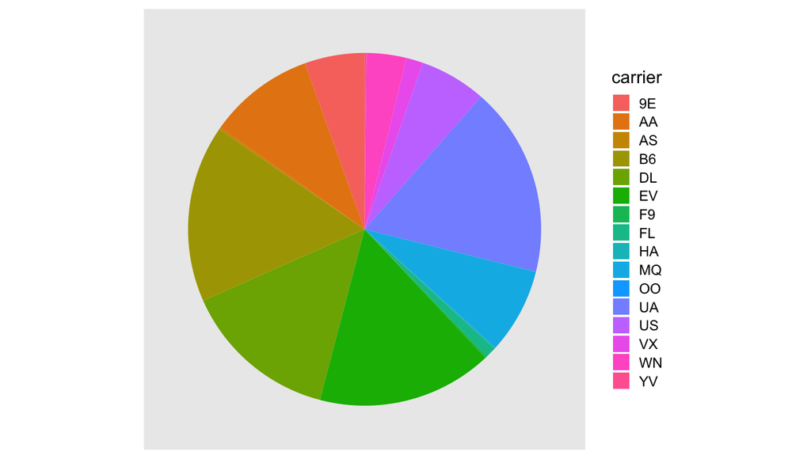